# chapter 2 Linear regression

*Describe the work you have done this week and summarize your learning.*

- Describe your work and results clearly.
- Assume the reader has an introductory course level understanding of writing and reading R code as well as statistical methods.
- Assume the reader has no previous knowledge of your data or the more advanced methods you are using.

```r
date()
```

```
## [1] "Fri Nov 12 09:46:46 2021"
```

Here we go again… In this chapter I practiced how to explore the raw data and build a linear regression; (Creat lists with a dash)

- 1 load the data to local memory
- 2 explore the original data by selecting and filter (With R markdown, you can insert R code chunks including table and plots:)

```r
# quick summary of sudent2014 data
# library(dplyr)
library(ggplot2)
library(GGally)
# Load the student2014 data set
stu14 <- read.csv('http://s3.amazonaws.com/assets.datacamp.com/production/course_2218/datasets/learning2014.txt')
# Summary the student2014
summary(stu14)
```

```
##     gender               age           attitude          deep
##  Length:166         Min.   :17.00   Min.   :1.400   Min.   :1.583
##  Class :character   1st Qu.:21.00   1st Qu.:2.600   1st Qu.:3.333
##  Mode  :character   Median :22.00   Median :3.200   Median :3.667
##                     Mean   :25.51   Mean   :3.143   Mean   :3.680
##                     3rd Qu.:27.00   3rd Qu.:3.700   3rd Qu.:4.083
##                     Max.   :55.00   Max.   :5.000   Max.   :4.917
##       stra            surf           points
##  Min.   :1.250   Min.   :1.583   Min.   : 7.00
##  1st Qu.:2.625   1st Qu.:2.417   1st Qu.:19.00
##  Median :3.188   Median :2.833   Median :23.00
##  Mean   :3.121   Mean   :2.787   Mean   :22.72
##  3rd Qu.:3.625   3rd Qu.:3.167   3rd Qu.:27.75
##  Max.   :5.000   Max.   :4.333   Max.   :33.00
```

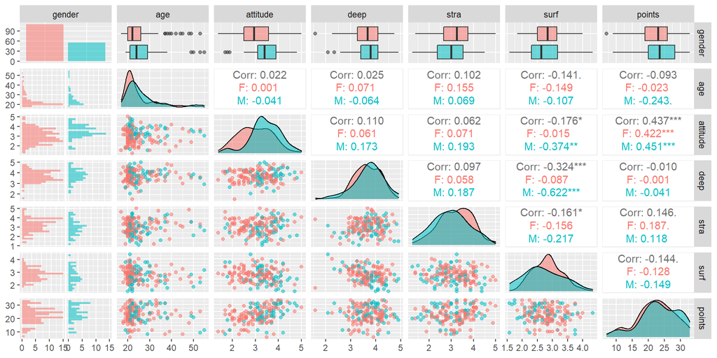

```r
# Print the paris plots
p <- ggpairs(stu14, mapping = aes(col = gender,alpha = 0.3),
         lower = list(combo = wrap("facethist", bins = 20)))
p
```

- 3 before build the regression, the pairs could help we to identify the potential explanatory variables

```r
# As the pair correlation showed,
# the points as respond, the attitude, stra and surf as the explantory variables
model <- lm(points ~ attitude + stra + surf , data = stu14)
summary(model)
```

```
##
## Call:
## lm(formula = points ~ attitude + stra + surf, data = stu14)
##
## Residuals:
##      Min       1Q   Median       3Q      Max
## -17.1550  -3.4346   0.5156   3.6401  10.8952
##
## Coefficients:
##             Estimate Std. Error t value Pr(>|t|)
## (Intercept)  11.0171     3.6837   2.991  0.00322 **
## attitude      3.3952     0.5741   5.913 1.93e-08 ***
## stra          0.8531     0.5416   1.575  0.11716
## surf         -0.5861     0.8014  -0.731  0.46563
## ---
## Signif. codes:  0 '***' 0.001 '**' 0.01 '*' 0.05 '.' 0.1 ' ' 1
##
## Residual standard error: 5.296 on 162 degrees of freedom
## Multiple R-squared:  0.2074, Adjusted R-squared:  0.1927
## F-statistic: 14.13 on 3 and 162 DF,  p-value: 3.156e-08
```

- 4 the model could be conduce perfectly at first time, we could improve it generally

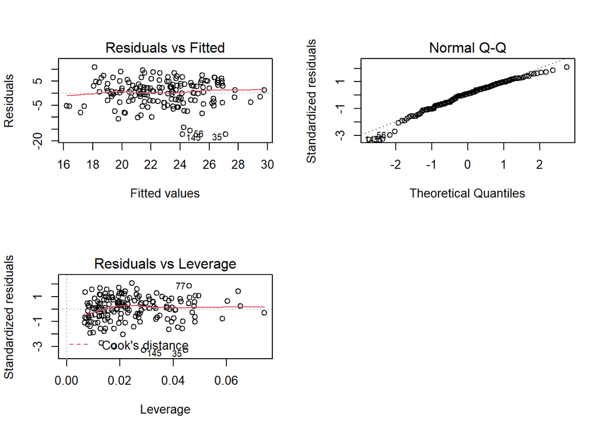

```r
# Examine the model
par(mfrow = c(2,2))
plot(model, which = c(1,2,5))
```

- 5 the improving processes would use diagnostic plots and the summary of models

```r
# rebuild the fitted model
stu14_2 <- stu14[-c(35,56,77,145),] #162*7
model2 <- lm(points ~ attitude + stra , data = stu14_2)
summary(model2)
```

```
##
## Call:
## lm(formula = points ~ attitude + stra, data = stu14_2)
##
## Residuals:
##      Min       1Q   Median       3Q      Max
## -14.3637  -3.3478   0.3832   3.4120  11.2988
##
## Coefficients:
##             Estimate Std. Error t value Pr(>|t|)
## (Intercept)   7.1543     2.1723   3.293  0.00122 **
## attitude      3.8961     0.5124   7.604 2.35e-12 ***
## stra          1.1433     0.4828   2.368  0.01909 *
## ---
## Signif. codes:  0 '***' 0.001 '**' 0.01 '*' 0.05 '.' 0.1 ' ' 1
##
## Residual standard error: 4.747 on 159 degrees of freedom
## Multiple R-squared:  0.2921, Adjusted R-squared:  0.2832
## F-statistic: 32.81 on 2 and 159 DF,  p-value: 1.18e-12
```

- 6 finally, we could get a improved and acceptable models, otherwise, the linear regression would not fit the case, we should look for nonlinear regressions, such as GLM.

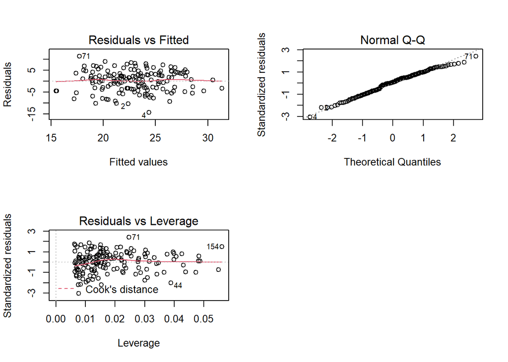

```r
# the r2 has been improved a bit in model2, from 0.21 to 0.29
# the diagnostic plots for model 2
par(mfrow = c(2,2))
plot(model2, which = c(1,2,5))
```